# Coursework Report

*N* removed NAs: 3

*N* removed typo: 1

*N* removed <18: 28

*N* total clean: 118

| Group | *N* | *M*<sub>age</sub> | *M*<sub>rating</sub> |
| --- | --- | --- | --- |
| Control | 55 | 21.33 | 6.52 |
| Experim | 63 | 21.05 | 5.59 |

**Main analysis results**

*t*(116) = 6.08, *p* < .001

[interactive chart not shown]

[figure not shown]

[interactive chart not shown]

# Coursework Report

Analysing Data, Spring 2020

# Methods

## Design

The study’s hypothesises is that when women see the colour red it increases their attraction to the man more than the colour white. The research question is does viewing a red colour frame rather than a white frame around an image of a man influence the mean ratings of his attractiveness? The independent variable is the colour of the frame which is a factor, those who are in the control group will see a white frame and those in the experimental group will see a red frame. This is on two levels and is the predicator. The dependent variable is attractiveness which is measured by ratings of 1-9 on three questions. The answers are then averaged to get a composite score, the higher the rating means that the women found the man more attractive. This is the outcome. The operational hypothesis is that viewing a red frame around an image of a moderately attract man will influence the mean rating of his attractiveness. A t-test will be used for the statistical analysis.

# Results

The results show that the mean attraction score of the control group is higher than the mean attraction score of the experimental group, so that means the control group found the photo of the man more attractive.

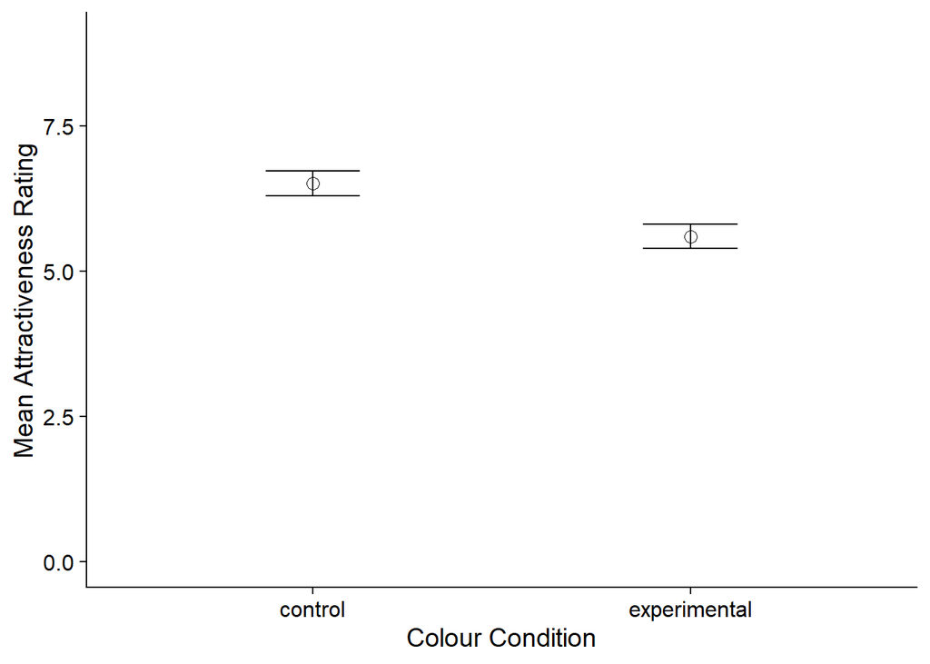

An independent-measures *t*-test was used to analyse the effect colour had on attractiveness rating. The analysis indicated that those in the control group had a higher mean attraction rating (*M* = 6.52) than those in the experimental group (*M* = 5.59). This difference in means was significant (*M*<sub>diff</sub> = 0.93, 95% CI [0.63, 1.23], *t* (116) = 6.08, *p* = 0). The difference between the control mean and the experimental mean is 0.93 so the null hypothesis should be rejected as it is not equal to 0. This is significant as *p*= .00000001551 which is very small so the alternative hypothesis can be accepted. Therefore this analysis shows that the colour of the frame around a photo of a man does affect how women rate his attractiveness, specifically having a white frame increases attraction ratings more than having a red frame.

# Discussion

The results show that the control group rated the photo of the man higher than the experimental group. This means that the colour white increases attractiveness ratings more than the colour red. This doesn’t support the hypothesis which stated that the colour red would increase attraction ratings more than the colour white as the opposite effect was found.

In Elliot et al.’s (2010) original study it was found that having a red frame on the photo of a moderately attractive man increased women’s attractiveness ratings more than the white frame did. This replication of Elliot et al.’s (2010) study found the opposite pattern as having a white frame increased attraction ratings more than having a red frame. This could mean that it isn’t the colour of the frame influencing the attraction ratings but instead an extraneous variable as they results were different despite the same method being used.

This study had 118 participants whereas Elliot et al.’s (2010) study had only has 21 participants making this replication more representative of the target population which is why the results may be different to the original study. However in Elliot et al.’s (2010) study they asked the participants what they thought the study was about and no one guessed the aim but this didn’t happen in this study so the results may be different because the participants guessed the aim of the study and acted differently. The results aren’t reliable as this study found different results to the original so it is unlikely that colour does actually have an effect on how women perceive the attractiveness of men.

This research is worth investigating further, as although the results showing the effect of frame colour on attractiveness was unreliable, the results from this study were statistically significant. Colour effect may have an effect when it is the clothes the man is wearing or an object he is holding. For example Lin (2014) found that women holding a red laptop were rated more attractive than when they were holding a black, silver or blue laptop. It could also be investigated further by using homosexual male participants as well as the female participants to investigate whether there is a gender difference when it comes to the colour effect on attraction. Both this study and Elliot et al.’s (2010) study had young participants ranging from 18-27, so it may be important to investigate how colour affects attraction ratings in an older population. Although there has been research showing that colour-effect may be more dominant on a younger target (Schwarz & Singer, 2013), there hasn’t been a replication of Elliot et al. (2010) using an older population. If results are found that show an age difference of colour effect on attraction it would suggest that there might be cognitive processes that change over time influencing the ratings.

In conclusion the results from this study show that white frames increase perceived attractiveness of men more than red frames. This had the opposite effect to Elliot et al. (2010) results who found red increased attraction ratings more making it lack reliability. However it is worth investigating colour effect more as it may have an effect when investigating clothes colour, object colour or using homosexual males and older participants.

# References

Elliot, A. J., Kayser, D. N., Greitemeyer, T., Lichtenfeld, S., Gramzow, R. H., Maier, M. A., & Liu, H. (2010). Red, rank, and romance in women viewing men. Journal of Experimental Psychology. General, 139(3), 399–417. https://doi.org/10.1037/a0019689

Lin, H. (2014). Red-colored products enhance the attractiveness of women. Displays, 35(4), 202–205. https://doi.org/10.1016/j.displa.2014.05.009 Peperkoorn, L. S., Roberts, S. C., & Pollet, T. V. (2016). Revisiting the red effect on attractiveness and sexual receptivity: No effect of the color red on human mate preferences. Evolutionary Psychology, 14(4), 1474704916673841. https://doi.org/10.1177/1474704916673841

Schwarz, S., & Singer, M. (2013). Romantic red revisited: Red enhances men’s attraction to young, but not menopausal women. Journal of Experimental Social Psychology, 49(1), 161–164. https://doi.org/10.1016/j.jesp.2012.08.004